# R Notebook

# Levantamento das coletas sobre os tribunais

Os tribunais requisitados para esta apresentação foram os TRFs e TJs, entre eles,

1. TRF
   1. TRF-1
   2. TRF-2
   3. TRF-3
   4. TRF-5
2. TJ
   1. TJSP
   2. TJAL
   3. TJDFT
   4. TJRJ

Alguns deles não estão na análise, pois foram retirados para realizar uma coleta mais consistente, como por exemplo, o `TRF-2` ou tiveram problemas na coleta como `TJRJ`. Além disso, cabe destacar que o caso do `TRF-5` precisa ser discutido, pois a maioria das decisões não são capazes de informar o arquivamento ou não dos casos (irei explorar este caso ao longo do relatório).

## TRFs

### TRF-1

```r
trf1_2 <- trf1 %>% mutate(num_proc = str_replace_all(processo, "[^0-9]", ""),
                num_proc = str_trim(num_proc)) %>%
  distinct(num_proc, .keep_all = T)
```

[output not shown]

```
1. Número de processos em segunda instância levantados.
```

```r
trf1_2 %>% nrow()
```

```
[1] 315
```

```
2. Taxa de arquivamento nos processos de segunda instância
```

Para obter a taxa de arquivamento nos processos, basta procurar, por meio de `regex`, palavras que podem estar relacionadas com tal ação. As palavras escolhidas e suas variações foram, *rejeitar*, *declarar extinta* e *arquivou*

| tx_arquivamento |
| --- |
| 0.5365079 |

### TRF-2

Nova coleta em andamento.

### TRF-3

```r
glimpse(trf3)
```

```
Observations: 147
Variables: 17
$ acordao                    <chr> "Vistos e relatados estes autos em que são partes as acima indica...
$ `data_da_publicacao/fonte` <chr> "e-DJF3 Judicial 1 DATA:29/11/2017", "e-DJF3 Judicial 1 DATA:28/0...
$ data_do_julgamento         <chr> "16/11/2017", "20/07/2017", "20/04/2017", "16/03/2017", "16/03/20...
$ ementa                     <chr> "PENAL. PROCESSO PENAL. CORRUPÇÃO PASSIVA E ATIVA. PREVARICAÇÃO. ...
$ orgao_julgador             <chr> "QUARTA SEÇÃO", "QUARTA SEÇÃO", "QUARTA SEÇÃO", "QUARTA SEÇÃO", "...
$ processo                   <chr> "IP - INQUÉRITO POLICIAL - 1459 / SP   0008080-69.2016.4.03.0000"...
$ referencia_legislativa     <chr> "***** CPP-41  CÓDIGO DE PROCESSO PENALLEG-FED DEL-3689  ANO-1941...
$ `relator(a)`               <chr> "DESEMBARGADOR FEDERAL MAURICIO KATO", "DESEMBARGADOR FEDERAL MAU...
$ sucessivos                 <chr> NA, "PROC: IP 2014.60.05.000448-5/MS ÓRGÃO: QUARTA SEÇÃO JUIZ: DE...
$ resumo_estruturado         <chr> NA, NA, NA, "VIDE EMENTA.", NA, NA, "VIDE EMENTA.", NA, NA, NA, "...
$ veja                       <chr> NA, NA, NA, NA, NA, NA, NA, "STJ HC 153.097/DF", NA, NA, NA, NA, ...
$ `relator(a)_para_acordao`  <chr> NA, NA, NA, NA, NA, NA, NA, NA, NA, NA, NA, NA, NA, NA, NA, NA, N...
$ precedentes                <chr> NA, NA, NA, NA, NA, NA, NA, NA, NA, NA, NA, NA, NA, NA, NA, NA, N...
$ doutrina                   <chr> NA, NA, NA, NA, NA, NA, NA, NA, NA, NA, NA, NA, NA, NA, NA, NA, N...
$ outras_fontes              <chr> NA, NA, NA, NA, NA, NA, NA, NA, NA, NA, NA, NA, NA, NA, NA, NA, N...
$ notas                      <chr> NA, NA, NA, NA, NA, NA, NA, NA, NA, NA, NA, NA, NA, NA, NA, NA, N...
$ revisor                    <chr> NA, NA, NA, NA, NA, NA, NA, NA, NA, NA, NA, NA, NA, NA, NA, NA, N...
```

```
1. Número de processos em segunda instância levantados.
```

```r
trf3_2 %>% nrow()
```

```
[1] 138
```

```
2. Taxa de arquivamento nos processos de segunda instância
```

Para obter a taxa de arquivamento nos processos, basta procurar, por meio de `regex`, palavras que podem estar relacionadas com tal ação. As palavras escolhidas e suas variações foram, *rejeitar*, *declarar extinta* e *arquivou*

| tx_arquivamento |
| --- |
| 0.5289855 |

### TRF-5

| decisao | n |
| --- | --- |
| À unanimidade, em preliminar, firmar a competência do TRF/5ª Região para julgamento da presente demanda e, no mérito, por maioria, DECRETAR A ABSOLVIÇÃO SUMÁRIA DOS ACUSADOS. | 1 |
| DECIDE O PLENÁRIO DO TRF, POR UNANIMIDADE, REJEITAR A DENÚNCIA\nQUANTO AO INDICIADO LUIZ GONZAGA NOGUEIRA E, POR MAIORIA, REJEITAR\nA DENUÚNCIA QUANTO AO INDICIADO JOSÉ ROBENILSON FERREIRA. | 1 |
| MAIORIA, rejeitar a preliminar de incompetência da Justiça Federal, e, à UNANIMIDADE, rejeitar a preliminar de conexão para, no mérito, REJEITAR A DENÚNCIA, considerando prejudicado o exame das demais… | 1 |
| POR MAIORIA | 135 |
| POR MAIORIA, INDEFERIR A PRELIMINAR DE INCOMPETÊNCIA, E, À UNANIMIDADE, RECEBER A DENÚNCIA QUANTO AO ACUSADO ANTÔNIO NARCÉLIO RODRIGUESPONTE E, QUANTO A LUIZ DE SENA DIAS. | 1 |
| POR UNANIMIDADE, ACOLHER A PRELIMINAR DE INCOMPETÊNCIA ABSOLUTA E, POR MAIORIA, DETERMINAR A REMESSA DOS AUTOS À JUSTIÇA FEDERAL DE 1º GRAU DO CEARÁ, NOS TERMOS DO VOTO DO RELATOR E DAS NOTAS TAQUIGRÁ… | 1 |
| POR UNANIMIDADE, DECLINAR DA COMPETÊNCIA EM FAVOR DA JUSTIÇA FEDERAL DA 1ª INSTÂNCIA E, POR MAIORIA, DENEGAR HABEAS CORPUS DE OFÍCIO. | 1 |
| POR UNANIMIDADE, DECLINAR DA COMPETÊNCIA, E POR MAIORIA, DETERMINAR A REMESSA DOS AUTOS À JUSTIÇA FEDERAL DE 1º GRAU DO CEARÁ. | 1 |
| Por unanimidade, receber a denúncia, e, por maioria, determinar o afastamento do Prefeito do exercício do cargo | 1 |
| POR UNANIMIDADE, RECEBER A DENÚNCIA, POR MAIORIA, DETERMINOU O ENCAMINHAMENTO DOS AUTOS AO MINISTÉRIO PÚBLICO FEDERAL PARA SE PRONUNCIAR SOBRE A SUSPENSÃO CONDICIONAL DO PROCESSO, | 1 |

[output cut: 1 more lines]

```
1. Número de processos em segunda instância levantados.
```

```r
trf5 %>% nrow()
```

```
[1] 857
```

```
2. Taxa de arquivamento nos processos de segunda instância
```

Para obter a taxa de arquivamento nos processos, basta procurar, por meio de `regex`, palavras que podem estar relacionadas com tal ação. As palavras escolhidas e suas variações foram, *rejeitar*, *declarar extinta* e *arquivou*

| tx_arquivamento |
| --- |
| 0.002333722 |

O resultado baixo se dá devido a forma como a decisão está disposta.

## Visualização gráfica

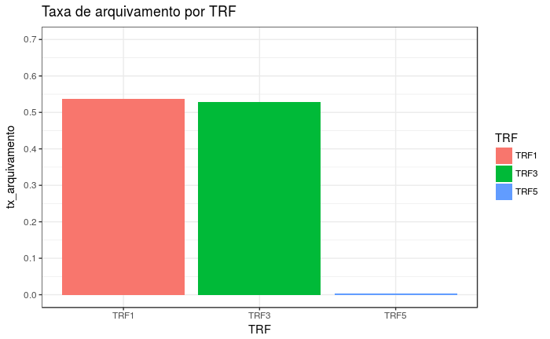

## TJ

### TJSP

```r
glimpse(tjsp)
```

```
Observations: 1,001
Variables: 6
$ id        <chr> "00000547820148260000", "00003021520128260000", "00007602720158260000", "000121968...
$ file      <chr> "/home/nathang/Documentos/Scripts and Documents/ESTAGIO_ABJ/ABJ/tjs/jurisprudencia...
$ hidden    <lgl> FALSE, FALSE, FALSE, FALSE, FALSE, FALSE, FALSE, FALSE, FALSE, FALSE, FALSE, FALSE...
$ data      <list> [<# A tibble: 12 x 2,    data              value                 ...
$ movs      <list> [<# A tibble: 53 x 2,    movement   description                  ...
$ decisions <list> [<# A tibble: 1 x 2,   date       decision                       ...
```

```
1. Número de processos em segunda instância levantados.
```

```r
tjsp_2 %>% nrow()
```

```
[1] 1001
```

```
2. Taxa de arquivamento nos processos de segunda instância
```

Para obter a taxa de arquivamento nos processos, basta procurar, por meio de `regex`, palavras que podem estar relacionadas com tal ação. As palavras escolhidas e suas variações foram, *rejeitar*, *declarar extinta* e *arquivou*

| tx_arquivamento |
| --- |
| 0.7623666 |

## TJAL

[output not shown]

```r
glimpse(tjal)
```

```
Observations: 8
Variables: 5
$ value          <chr> "/home/nathang/Documentos/Scripts and Documents/ESTAGIO_ABJ/ABJ/tjs/consulta_...
$ dados_processo <list> [<Criminal, Improbidade Administrativa, Ação Penal - Procedimento Ordinário,...
$ partes         <list> [<Ministério Público, Carlos Alberto Moreira de Mendonça Canuto

     ...
$ movimentacao   <list> [<# A tibble: 219 x 2,    data       movimento              ...
$ julgamento     <list> [<12/05/2015, Julgado, à unanimidade de votos, em rejeitar as preliminares d...
```

```
1. Número de processos em segunda instância levantados.
```

```r
tjal %>% nrow()
```

```
[1] 8
```

```
2. Taxa de arquivamento nos processos de segunda instância
```

Para obter a taxa de arquivamento nos processos, basta procurar, por meio de `regex`, palavras que podem estar relacionadas com tal ação. As palavras escolhidas e suas variações foram, *rejeitar*, *declarar extinta* e *arquivou*

| tx_arquivamento |
| --- |
| 0.375 |

## TJDFT

```r
tjdft <- readr::read_rds("tjs/jurisprudencia/TJDFT/data-raw/rds_files/data.rds")
```

[output not shown]

```
1. Número de processos em segunda instância levantados.
```

```r
tjdft %>% nrow()
```

```
[1] 80
```

```
2. Taxa de arquivamento nos processos de segunda instância
```

Para obter a taxa de arquivamento nos processos, basta procurar, por meio de `regex`, palavras que podem estar relacionadas com tal ação. As palavras escolhidas e suas variações foram, *rejeitar*, *declarar extinta* e *arquivou*

```r
tx_tjdft <- tjdft %>%
  mutate(decisao = str_to_lower(decisao),
         decisao = abjutils::rm_accent(decisao),
         decisao = str_replace_all(decisao, "[[:punct:]]", " "),
         declar_dummy = case_when(str_detect(decisao, "(declar[(amos)|(ou)])")~1,
                                        T~0),
         extinta_dummy = case_when(str_detect(decisao, "(extinta)")~1,
                                        T~0),
         arquivamento_dummy = case_when(declar_dummy == 1 & extinta_dummy == 1| str_detect(decisao, "(rejeit)|(arquiv)") ~1,
                                        T~0)) %>%
  summarise(tx_arquivamento = mean(arquivamento_dummy))

tx_tjdft
```

[output not shown]

## Visualização gráfica

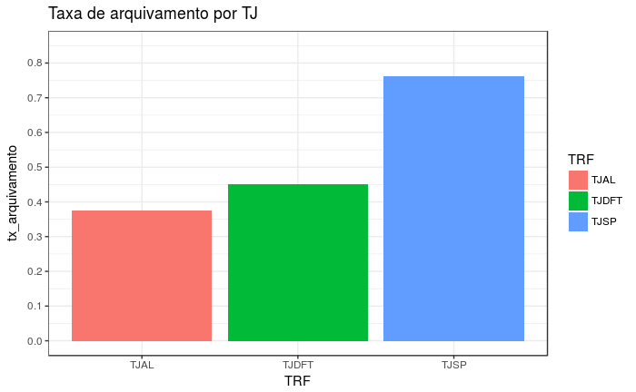